# Assignment5

Briana Flynn

10/2/2020

# Instructions

Estimate at least one more version of the regression you estimated in Assignment 4 by transforming one or more of the independent variables and including at least one interaction term. Which version of the model best explains the observed variation in your dependent variable?

```r
library(tidyverse)
library(jtools)
library(interactions)
library(knitr)
library(huxtable)
library(ggstance)
library(broom.mixed)
```

```r
hh_data <- read_csv("households.csv") %>%
  mutate(children = case_when(
    HUPAC_label=="No children" ~ "None",
    HUPAC_label=="With children 6 to 17 years only" ~ "6 to 17",
    HUPAC_label=="With children under 6 years and 6 to 17 years" ~ "0 to 17",
    HUPAC_label=="With children under 6 years only" ~ "0 to 6")) %>%
  mutate(internet = case_when(
    ACCESS_label=="Yes, by paying a cell phone company or Internet service provider" ~ "Yes",
    ACCESS_label=="Yes, without paying a cell phone company or Internet service provider" ~ "Yes",
    ACCESS_label=="No access to the Internet at this house, apartment, or mobile home" ~ "No")) %>%
  mutate(engl_prof =
           LNGI_label == "At least one person in the household 14 and over speaks English only or speaks English 'very well'") %>%
  filter(HINCP > 0)
```

# Testing log-transformations and interactions to improve model fit

## Model 1: Initial Model

For this assignment, I’ve revised my dependent and independent variables after feedback during Monday’s class. I learned that my r-squared values were so high for Assignment 4 because of the direct relationship between rent, household income, and rent burden. For this assignment, I’ve removed monthly rent from my variables, and have made rent burden my dependent variable. I am now looking at how household income, internet access, English proficiency, and presence of children impact rent burden level.

```r
options(scipen = 999)
model1 <- lm(GRPIP ~ HINCP + engl_prof + children + internet,
            data = hh_data)

summary(model1)
```

```
##
## Call:
## lm(formula = GRPIP ~ HINCP + engl_prof + children + internet,
##     data = hh_data)
##
## Residuals:
##     Min      1Q  Median      3Q     Max
## -36.019 -10.538  -3.668   6.055  77.810
##
## Coefficients:
##                     Estimate   Std. Error t value             Pr(>|t|)
## (Intercept)     42.697608610  0.672751231  63.467 < 0.0000000000000002 ***
## HINCP           -0.000123217  0.000001692 -72.806 < 0.0000000000000002 ***
## engl_profTRUE   -0.923746018  0.445647031  -2.073               0.0382 *
## children0 to 6  -1.484983042  0.579051640  -2.565               0.0103 *
## children6 to 17  0.644869078  0.501970338   1.285               0.1989
## childrenNone    -2.315846400  0.449687688  -5.150          0.000000264 ***
## internetYes      0.683212198  0.462635976   1.477               0.1398
## ---
## Signif. codes:  0 '***' 0.001 '**' 0.01 '*' 0.05 '.' 0.1 ' ' 1
##
## Residual standard error: 16.24 on 16142 degrees of freedom
## Multiple R-squared:  0.2647, Adjusted R-squared:  0.2644
## F-statistic: 968.5 on 6 and 16142 DF,  p-value: < 0.00000000000000022
```

## Model 2: Log-transformed Income

```r
model2 <- lm(GRPIP ~ log(HINCP) + engl_prof + children + internet,
    data = hh_data)

summary(model2)
```

```
##
## Call:
## lm(formula = GRPIP ~ log(HINCP) + engl_prof + children + internet,
##     data = hh_data)
##
## Residuals:
##     Min      1Q  Median      3Q     Max
## -61.060  -8.891  -1.449   6.358  62.424
##
## Coefficients:
##                 Estimate Std. Error t value             Pr(>|t|)
## (Intercept)     184.3574     1.5561 118.473 < 0.0000000000000002 ***
## log(HINCP)      -14.4984     0.1458 -99.458 < 0.0000000000000002 ***
## engl_profTRUE     2.1107     0.4075   5.179       0.000000225419 ***
## children0 to 6   -1.1023     0.5253  -2.098               0.0359 *
## children6 to 17   0.5992     0.4556   1.315               0.1885
## childrenNone     -2.6073     0.4078  -6.394       0.000000000166 ***
## internetYes       6.2218     0.4286  14.515 < 0.0000000000000002 ***
## ---
## Signif. codes:  0 '***' 0.001 '**' 0.01 '*' 0.05 '.' 0.1 ' ' 1
##
## Residual standard error: 14.74 on 16142 degrees of freedom
## Multiple R-squared:  0.3944, Adjusted R-squared:  0.3941
## F-statistic:  1752 on 6 and 16142 DF,  p-value: < 0.00000000000000022
```

## Model 3: Interactions with Log-transformed Household Income

```r
model3 <- lm(GRPIP ~ log(HINCP) + engl_prof + children + internet + engl_prof:log(HINCP) +
               internet:log(HINCP),
            data = hh_data)

summary(model3)
```

```
##
## Call:
## lm(formula = GRPIP ~ log(HINCP) + engl_prof + children + internet +
##     engl_prof:log(HINCP) + internet:log(HINCP), data = hh_data)
##
## Residuals:
##     Min      1Q  Median      3Q     Max
## -56.173  -8.870  -1.556   6.519  62.298
##
## Coefficients:
##                          Estimate Std. Error t value             Pr(>|t|)
## (Intercept)              128.1487     6.1103  20.973 < 0.0000000000000002 ***
## log(HINCP)                -9.1222     0.5845 -15.608 < 0.0000000000000002 ***
## engl_profTRUE             38.7678     5.0720   7.643   0.0000000000000223 ***
## children0 to 6            -1.0120     0.5240  -1.931               0.0535 .
## children6 to 17            0.6547     0.4543   1.441               0.1496
## childrenNone              -2.3101     0.4078  -5.664   0.0000000150088989 ***
## internetYes               32.1353     5.0717   6.336   0.0000000002418208 ***
## log(HINCP):engl_profTRUE  -3.4729     0.4795  -7.242   0.0000000000004606 ***
## log(HINCP):internetYes    -2.4950     0.4869  -5.124   0.0000003021874684 ***
## ---
## Signif. codes:  0 '***' 0.001 '**' 0.01 '*' 0.05 '.' 0.1 ' ' 1
##
## Residual standard error: 14.7 on 16140 degrees of freedom
## Multiple R-squared:  0.3978, Adjusted R-squared:  0.3975
## F-statistic:  1333 on 8 and 16140 DF,  p-value: < 0.00000000000000022
```

When log-transforming household income and creating interaction terms between log-transformed household income and internet and English proficiency, the multiple R-squared value increases only very slightly to 0.3978.

# Comparing the Coefficients and P-Values of Each Model

```r
coeff_names <- c("Household Income" =
                   "HINCP",
                  "Household Income (log-transformed)" =
                   "log(HINCP)",
                 "English proficiency\n(vs. no English proficiency)" =
                   "engl_profTRUE",
                 "Internet access" =
                   "internetYes",
                 "Presence of children age 0 to 6" =
                   "children0 to 6",
                 "Presence of children age 6 to 17" =
                   "children6 to 17",
                 "No children" =
                   "childrenNone",
                 "Interaction:\nlog-transformed income and internet access" =
                   "log(HINCP):internetYes",
                 "Interaction:\nlog-transformed income and English proficiency" =
                   "log(HINCP):engl_profTRUE")


export_summs(model1, model2, model3,
             error_format = "(p = {p.value})",
             error_pos = "same",
             model.names = c("Model 1", "Model 2", "Preferred Model"),
             coefs = coeff_names)
```

|  | Model 1 | Model 2 | Preferred Model |
| --- | --- | --- | --- |
| Household Income | -0.00 *** (p = 0.00) |  |  |
| Household Income (log-transformed) |  | -14.50 *** (p = 0.00) | -9.12 *** (p = 0.00) |
| English proficiency (vs. no English proficiency) | -0.92 * (p = 0.04) | 2.11 *** (p = 0.00) | 38.77 *** (p = 0.00) |
| Internet access | 0.68 (p = 0.14) | 6.22 *** (p = 0.00) | 32.14 *** (p = 0.00) |
| Presence of children age 0 to 6 | -1.48 * (p = 0.01) | -1.10 * (p = 0.04) | -1.01 (p = 0.05) |
| Presence of children age 6 to 17 | 0.64 (p = 0.20) | 0.60 (p = 0.19) | 0.65 (p = 0.15) |
| No children | -2.32 *** (p = 0.00) | -2.61 *** (p = 0.00) | -2.31 *** (p = 0.00) |
| Interaction: log-transformed income and internet access |  |  | -2.50 *** (p = 0.00) |
| Interaction: log-transformed income and English proficiency |  |  | -3.47 *** (p = 0.00) |
| N | 16149 | 16149 | 16149 |
| R2 | 0.26 | 0.39 | 0.40 |
| *** p < 0.001; ** p < 0.01; * p < 0.05. |  |  |  |

When comparing the R-squared values of the three models, I see that the third model is my preferred model. The P-values for the second and third models are very similar.

# Visualizing Results

## R-Squared Values by Model

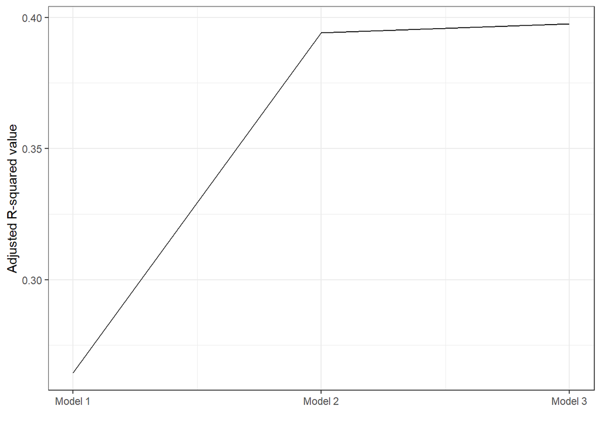

```r
ModelFit <- tibble(model = c(1, 2, 3),
                   R_square = c(summary(model1)$adj.r.squared,
                                summary(model2)$adj.r.squared,
                                summary(model3)$adj.r.squared))

ggplot(ModelFit, aes(x = model, y = R_square)) +
  geom_line() +
  scale_x_continuous(name = "",
                   breaks = breaks <- seq(1, 4, by = 1),
                   labels = paste("Model", breaks)) +
  scale_y_continuous(name = "Adjusted R-squared value") +
  theme_bw()
```

## Household Income’s Prediction of Rent Burden with Access to Internet Interaction

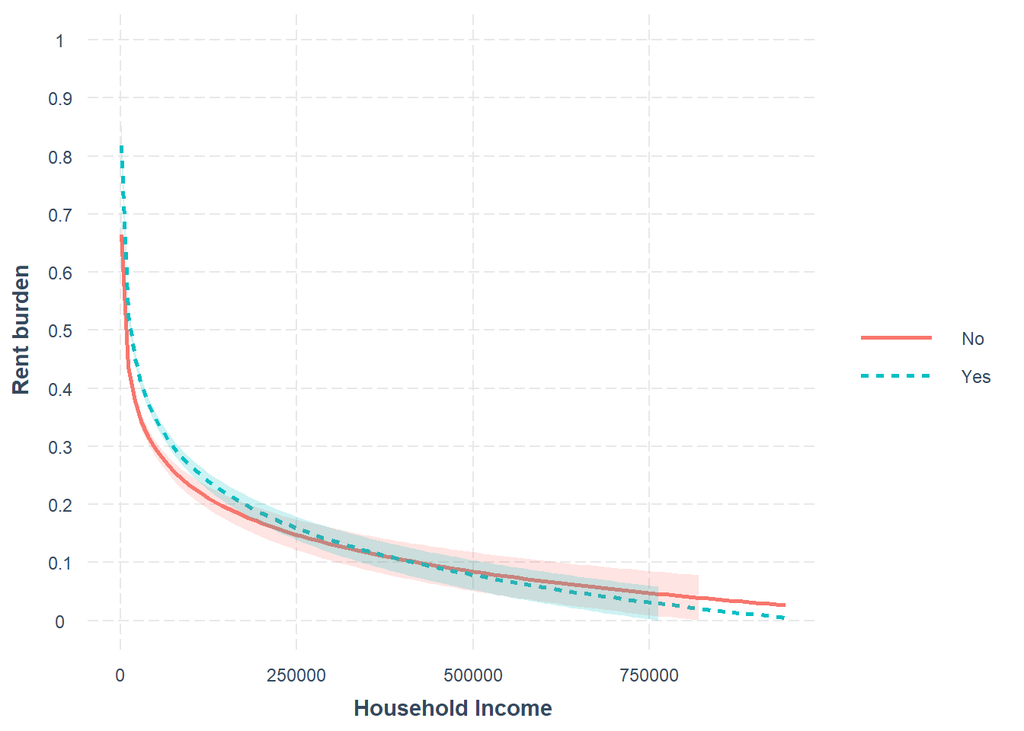

```r
interact_plot(model3, pred = HINCP, modx = internet, interval = TRUE) +
  scale_x_continuous(name = "Household Income")+
scale_y_continuous(name = "Rent burden",
                     limits = c(0, 100),
                     breaks = breaks <- seq(0, 100, by = 10),
                     labels = paste(prettyNum(breaks/100, big.mark = "'"),
                                    sep = "")) +
  scale_color_discrete(name = "") +
  scale_linetype_discrete(name = "") +
  scale_fill_discrete(name = "")
```